# Reproducible Research: Peer Assessment 1

- Loading and preprocessing the data
- What is mean total number of steps taken per day?
- What is the average daily activity pattern?
- Imputing missing values
- Are there differences in activity patterns between weekdays and weekends?

### Loading and preprocessing the data

Source data is in activity.zip file

##### The variables:

- steps: Number of steps made in a 5-minute interval (missing values are coded as NA)
- date: The date on which the measurement was taken in YYYY-MM-DD format
- interval: Identifier in minutes in which measurement was taken

##### Unzip & load the data

```r
unzip('activity.zip')
data <- read.csv('activity.csv', header = TRUE)
```

### What is mean total number of steps taken per day?

##### 1. Calculate the total number of steps taken per day

```r
data_per_day <- aggregate(steps ~ date, data=data, FUN = 'sum')
```

##### 2. Make a histogram of the total number of steps taken each day

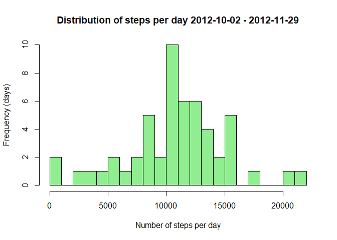

```r
hist(data_per_day$steps, xlab = 'Number of steps per day', ylab = 'Frequency (days)',
     main = 'Distribution of steps per day 2012-10-02 - 2012-11-29', col='lightgreen', breaks=20)
```

```r
data_per_day_mean <- mean(data_per_day$steps)
data_per_day_median <- median(data_per_day$steps)
```

### What is the average daily activity pattern?

##### 1. A time series plot of the 5-minute interval (x-axis) and the average number of steps taken, averaged across all days (y-axis)

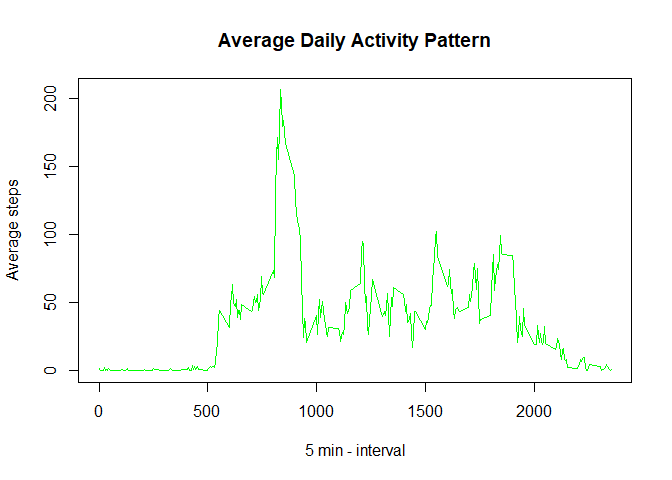

```r
data_per_interval <- aggregate(steps ~ interval, data=data, FUN = 'mean')

plot(data_per_interval$interval, data_per_interval$steps, type="l", xlab = "5 min - interval",
     ylab = "Average steps", main = "Average Daily Activity Pattern", col = "green")
```

##### 2. Which 5-minute interval, on average across all the days in the dataset, contains the maximum number of steps?

```r
data_per_interval$interval[which.max(data_per_interval$steps)]
```

```
## [1] 835
```

### Imputing missing values

##### 1. Total number of missing values in the dataset

```r
sum(is.na(data))
```

```
## [1] 2304
```

##### 3. Create a new dataset that is equal to the original dataset but with the missing data filled in.

```r
data_no_NAs <- data
data_no_NAs[is.na(data$steps), "steps"] <- 0
```

##### 4.1. Histogram of the total number of steps taken each day

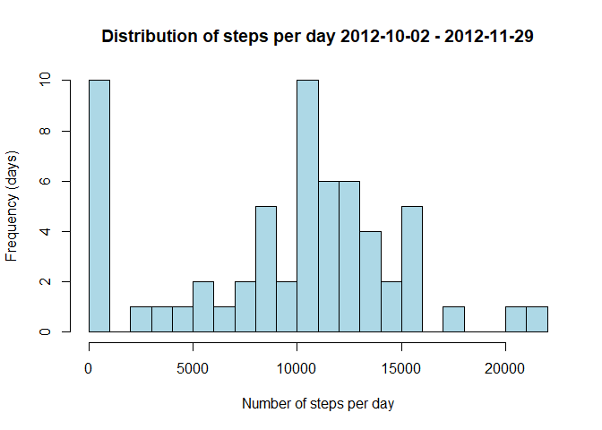

```r
data_per_day_no_NAs <- aggregate(steps ~ date, data=data_no_NAs, FUN = 'sum')

hist(data_per_day_no_NAs$steps, xlab = 'Number of steps per day', ylab = 'Frequency (days)',
     main = 'Distribution of steps per day 2012-10-02 - 2012-11-29', col='lightblue', breaks=20)
```

```r
data_per_day_mean_no_NAs <- mean(data_per_day_no_NAs$steps)
data_per_day_median_no_NAs <- median(data_per_day_no_NAs$steps)
```

### Are there differences in activity patterns between weekdays and weekends?

##### 1. Create a new factor variable in the dataset with two levels – “weekday” and “weekend” indicating whether a given date is a weekday or weekend day. (Sunday=0, Monday=1…)

```r
data_no_NAs$day <- as.POSIXlt(data_no_NAs$date)$wday
data_no_NAs$dayType <- as.factor(ifelse(data_no_NAs$day == 0 | data_no_NAs$day == 6, "weekend", "weekday"))

head(data_no_NAs)
```

```
##   steps       date interval day dayType
## 1     0 2012-10-01        0   1 weekday
## 2     0 2012-10-01        5   1 weekday
## 3     0 2012-10-01       10   1 weekday
## 4     0 2012-10-01       15   1 weekday
## 5     0 2012-10-01       20   1 weekday
## 6     0 2012-10-01       25   1 weekday
```

##### 2. Make a panel plot containing a time series plot (type=“l”) of the 5-minute interval (x-axis) and the average number of steps taken, averaged across all weekday days or weekend days (y-axis).

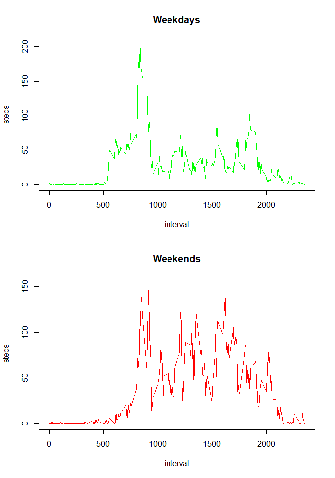

```r
weekday_Data <- data_no_NAs[data_no_NAs$dayType == "weekday",]
weekend_Data <- data_no_NAs[data_no_NAs$dayType == "weekend",]
data_per_weekday <- aggregate(steps ~ interval, weekday_Data, mean)
data_per_weekend <- aggregate(steps ~ interval, weekend_Data, mean)

par(mfrow = c(2, 1))

plot(data_per_weekday, type = "l", col = "green", main = "Weekdays")
plot(data_per_weekend, type = "l", col = "red", main = "Weekends")
```